# Project for Regression Models at Coursera

Xiang Jiang

August 23, 2014

### Executive summary

This project aims at answering the two questions:

- Is an automatic or manual transmission better for MPG?
- Quantify the MPG difference between automatic and manual transmissions.

We conclude that:

- Manual transmission is better than automatic for MPG.
- Compared with automatic transmissions, manual transmittions have an additional 2.94mpg.

### Exploratory Analysis

We begin by inspecting the distribution of mpg for different types of transmission, please find figure 1 in appendix.

```r
data(mtcars)
summary(mtcars$mpg[mtcars$am==0])
```

```
##    Min. 1st Qu.  Median    Mean 3rd Qu.    Max.
##    10.4    15.0    17.3    17.1    19.2    24.4
```

```r
sd(mtcars$mpg[mtcars$am==0])
```

```
## [1] 3.834
```

```r
summary(mtcars$mpg[mtcars$am==1])
```

```
##    Min. 1st Qu.  Median    Mean 3rd Qu.    Max.
##    15.0    21.0    22.8    24.4    30.4    33.9
```

```r
sd(mtcars$mpg[mtcars$am==1])
```

```
## [1] 6.167
```

### Model Selection & Fitting

Here we choose models by AIC in a stepwise algorithm.

```r
lm1 <- step(lm(mpg ~ ., data=mtcars))
```

Residual standard error for this model is:

```r
summary(lm1)$sigma
```

```
## [1] 2.459
```

To identify whether *wt* and *qsec* have significant influences to the model. We build models with and without *wt* and *qsec* respectively. We, then, use residual standard error to measure the performance of different models

The second model is:

```r
lm2 <- lm(mpg ~ am + wt, data=mtcars)
```

Residual standard error for this model is:

```r
summary(lm2)$sigma
```

```
## [1] 3.098
```

The third model is:

```r
lm3 <- lm(mpg ~ am + qsec, data=mtcars)
```

Residual standard error for this model is:

```r
summary(lm3)$sigma
```

```
## [1] 3.487
```

The fourth model is:

```r
lm4 <- lm(mpg ~ am, data=mtcars)
```

Residual standard error for this model is:

```r
summary(lm4)$sigma
```

```
## [1] 4.902
```

As we can see, the first model (lm(formula = mpg ~ wt + qsec + am, data = mtcars)) has the smallest residual standard error.

### Appendix

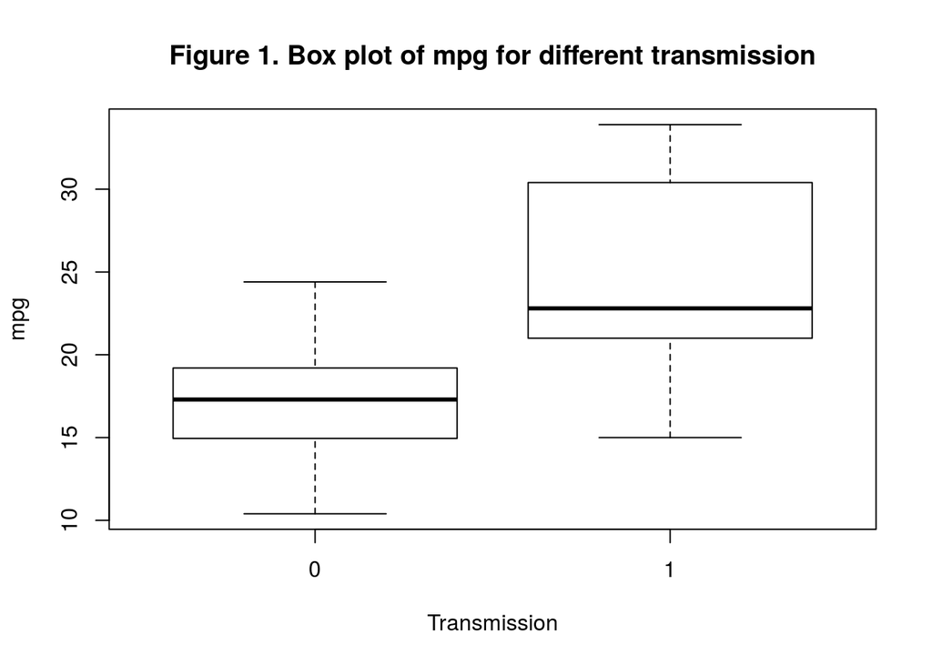

```r
boxplot(mtcars$mpg ~ mtcars$am,main='Figure 1. Box plot of mpg for different transmission', xlab='Transmission', ylab='mpg')
```

#### Figure 2. Residual Plot

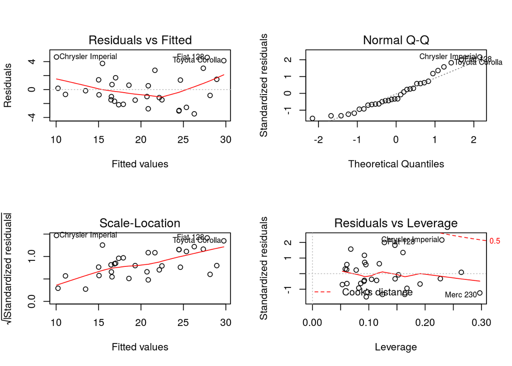

```r
par(mfrow = c(2, 2))
plot(lm1)
```